# IS 4487 Assignment 9: Customer Segmentation with Clustering

In this assignment, you will:

- Apply unsupervised learning to explore patterns in hotel booking behavior
- Use K-Means and Gaussian Mixture Models (GMM) for customer segmentation
- Evaluate model quality with metrics like Silhouette Score and Davies-Bouldin Index
- Connect clustering to actionable business insights

## Why This Matters

Businesses like hotels and travel platforms (e.g., Airbnb or Expedia) rely on customer segmentation to tailor promotions, pricing strategies, and service levels. Unlike supervised models, clustering helps uncover patterns when no labels exist—an ideal tool when entering new markets or analyzing unstructured customer behavior.

## Dataset Description: Hotel Bookings

This dataset contains booking information for two types of hotels: a **city hotel** and a **resort hotel**. Each record corresponds to a single booking and includes various details about the reservation, customer demographics, booking source, and whether the booking was canceled.

**Source**: [GitHub - TidyTuesday: Hotel Bookings](https://github.com/rfordatascience/tidytuesday/blob/master/data/2020/2020-02-11/readme.md)

### Key Use Cases

- Understand customer booking behavior
- Explore factors related to cancellations
- Segment guests based on booking characteristics
- Compare city vs. resort hotel performance

### Data Dictionary

| Variable | Type | Description |
| --- | --- | --- |
| `hotel` | character | Hotel type: City or Resort |
| `is_canceled` | integer | 1 = Canceled, 0 = Not Canceled |
| `lead_time` | integer | Days between booking and arrival |
| `arrival_date_year` | integer | Year of arrival |
| `arrival_date_month` | character | Month of arrival |
| `stays_in_weekend_nights` | integer | Nights stayed on weekends |
| `stays_in_week_nights` | integer | Nights stayed on weekdays |
| `adults` | integer | Number of adults |
| `children` | integer | Number of children |
| `babies` | integer | Number of babies |
| `meal` | character | Type of meal booked |
| `country` | character | Country code of origin |
| `market_segment` | character | Booking source (e.g., Direct, Online TA) |
| `distribution_channel` | character | Booking channel used |
| `is_repeated_guest` | integer | 1 = Repeated guest, 0 = New guest |
| `previous_cancellations` | integer | Past booking cancellations |
| `previous_bookings_not_canceled` | integer | Past bookings not canceled |
| `reserved_room_type` | character | Initially reserved room type |
| `assigned_room_type` | character | Room type assigned at check-in |
| `booking_changes` | integer | Number of booking modifications |
| `deposit_type` | character | Deposit type (No Deposit, Non-Refund, etc.) |
| `agent` | character | Agent ID who made the booking |
| `company` | character | Company ID (if booking through company) |
| `days_in_waiting_list` | integer | Days on the waiting list |
| `customer_type` | character | Booking type: Contract, Transient, etc. |
| `adr` | float | Average Daily Rate (price per night) |
| `required_car_parking_spaces` | integer | Requested parking spots |
| `total_of_special_requests` | integer | Number of special requests made |
| `reservation_status` | character | Final status (Canceled, No-Show, Check-Out) |
| `reservation_status_date` | date | Date of the last status update |

This dataset is ideal for classification, segmentation, and trend analysis exercises.

## 1. Setup and Load Data

Business framing:

Before we can cluster or segment anything, we need clean, accessible data in a usable format.

- Import the necessary Python libraries
- Load the hotel bookings dataset [(Download Here)](https://github.com/rfordatascience/tidytuesday/blob/main/data/2020/2020-02-11/readme.md#get-the-data-here)
- Display the first few rows

### In Your Response:

1. What stands out in the initial preview? Any columns or rows that seem unusual?

```python
# Add code here 🔧
```

```python
import pandas as pd
import matplotlib.pyplot as plt
import numpy as np
import seaborn as sns
```

```python
df = pd.read_csv('https://raw.githubusercontent.com/rfordatascience/tidytuesday/master/data/2020/2020-02-11/hotels.csv')
display(df.head())
```

|  | hotel | is_canceled | lead_time | arrival_date_year | arrival_date_month | arrival_date_week_number | arrival_date_day_of_month | stays_in_weekend_nights | stays_in_week_nights | adults | ... | deposit_type | agent | company | days_in_waiting_list | customer_type | adr | required_car_parking_spaces | total_of_special_requests | reservation_status | reservation_status_date |
| --- | --- | --- | --- | --- | --- | --- | --- | --- | --- | --- | --- | --- | --- | --- | --- | --- | --- | --- | --- | --- | --- |
| 0 | Resort Hotel | 0 | 342 | 2015 | July | 27 | 1 | 0 | 0 | 2 | ... | No Deposit | NaN | NaN | 0 | Transient | 0.0 | 0 | 0 | Check-Out | 2015-07-01 |
| 1 | Resort Hotel | 0 | 737 | 2015 | July | 27 | 1 | 0 | 0 | 2 | ... | No Deposit | NaN | NaN | 0 | Transient | 0.0 | 0 | 0 | Check-Out | 2015-07-01 |
| 2 | Resort Hotel | 0 | 7 | 2015 | July | 27 | 1 | 0 | 1 | 1 | ... | No Deposit | NaN | NaN | 0 | Transient | 75.0 | 0 | 0 | Check-Out | 2015-07-02 |
| 3 | Resort Hotel | 0 | 13 | 2015 | July | 27 | 1 | 0 | 1 | 1 | ... | No Deposit | 304.0 | NaN | 0 | Transient | 75.0 | 0 | 0 | Check-Out | 2015-07-02 |
| 4 | Resort Hotel | 0 | 14 | 2015 | July | 27 | 1 | 0 | 2 | 2 | ... | No Deposit | 240.0 | NaN | 0 | Transient | 98.0 | 0 | 1 | Check-Out | 2015-07-03 |

5 rows × 32 columns

### ✍️ Your Response: 🔧

1. Some things that stand out is theres NaN's for the agent and company columns. Additoinally, the some of the adr vlaues which is the average daily rate, are 0 which doesn't really make much sense.

## 2. Select and Prepare Features

Business framing:

A hotel might want to group guests based on how long they stay, how far in advance they book, or how likely they are to make special requests. You need to pick variables that represent meaningful guest behavior.

- Choose 3–5 numeric features related to customer behavior
- Drop missing values if needed
- Standardize using `StandardScaler`

### In Your Response:

1. What features did you select and why?
2. What kinds of patterns or segments do you expect to find?

```python
# Add code here 🔧
```

```python
initial_rows = df.shape[0]
df.dropna(subset=['lead_time', 'adr', 'days_in_waiting_list'], inplace=True)
rows_after_dropna = df.shape[0]
deleted_rows = initial_rows - rows_after_dropna
print(f"Number of rows deleted: {deleted_rows}")
```

```
Number of rows deleted: 0
```

```python
from sklearn.preprocessing import StandardScaler

features = ['lead_time', 'adr', 'days_in_waiting_list']
scaler = StandardScaler()
df[features] = scaler.fit_transform(df[features])
display(df[features].head())
```

|  | lead_time | adr | days_in_waiting_list |
| --- | --- | --- | --- |
| 0 | 2.227051 | -2.015038 | -0.131924 |
| 1 | 5.923385 | -2.015038 | -0.131924 |
| 2 | -0.907814 | -0.530935 | -0.131924 |
| 3 | -0.851667 | -0.530935 | -0.131924 |
| 4 | -0.842309 | -0.075810 | -0.131924 |

### ✍️ Your Response: 🔧

1. I selected lead time, adr, and days in waiting list. I selected these features because they were numerical and because they wern't dates/ years.
2. Some patterns and segments we expect to find, is groups of customers based on the average daily rates and how people plan their stays. For example row 0 most likely shows a budget planner because they booked quite a bit in advance and their average daily rate is very low.

## 3. Apply K-Means Clustering

Business framing:

Let’s say you’re working with the hotel’s marketing manager. She wants to group guests into a few clear types to target email campaigns. K-Means is a fast, simple way to try this.

- Fit a `KMeans` model with your selected features
- Choose a value of `k` (e.g. 3, 4, or 5)
- Predict clusters and assign to each guest
- Visualize using a scatterplot of 2 features

Much of this assignment has already been covered in the lab. Please be sure to complete the lab before the assignment.

### In Your Response:

1. What `k` value did you choose, and how did you decide?
2. What types of customers seem to show up in the clusters?

```python
# Add code here 🔧
```

```python
from sklearn.cluster import KMeans

kmeans = KMeans(n_clusters=4, random_state=42, n_init=10)
df['kmeans_cluster'] = kmeans.fit_predict(df[features])
display(df.groupby('kmeans_cluster')[features].mean())
```

| kmeans_cluster | lead_time | adr | days_in_waiting_list |
| --- | --- | --- | --- |
| 0 | -0.526417 | -0.498735 | -0.091559 |
| 1 | 1.466987 | -0.258962 | -0.023704 |
| 2 | 1.320411 | -0.328512 | 8.106562 |
| 3 | -0.323110 | 1.229796 | -0.121471 |

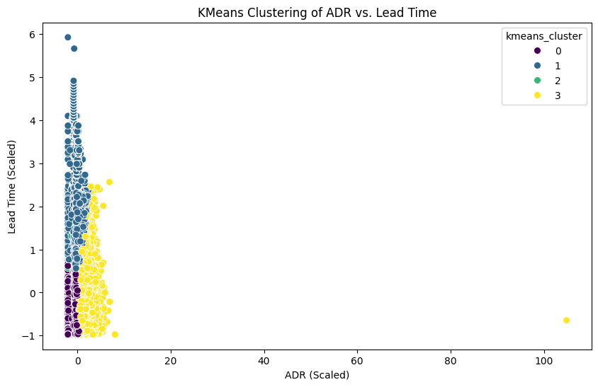

```python
plt.figure(figsize=(10, 6))
sns.scatterplot(x='adr', y='lead_time', hue='kmeans_cluster', data=df, palette='viridis', s=50, legend='full')
plt.title('KMeans Clustering of ADR vs. Lead Time')
plt.xlabel('ADR (Scaled)')
plt.ylabel('Lead Time (Scaled)')
plt.show()
```

## 4. Apply Gaussian Mixture Model (GMM)

Business framing:

Not all guests fit neatly into one cluster. GMM lets us capture uncertainty — useful if customers behave similarly across groups.

- Fit a GMM with the same number of clusters you chose in Part 3
- Predict soft clusters (remember that soft clustering deals with probabilities, not labels)
- Visualize the GMM model so that you may compare it to the KMeans scatterplot

### In Your Response:

1. How did the GMM results compare to KMeans?
2. What business questions might GMM help answer better?

```python
# Add your code here
```

```python
from sklearn.mixture import GaussianMixture

gmm = GaussianMixture(n_components=4, random_state=42)
gmm.fit(df[features])
```

```
GaussianMixture(n_components=4, random_state=42)
```

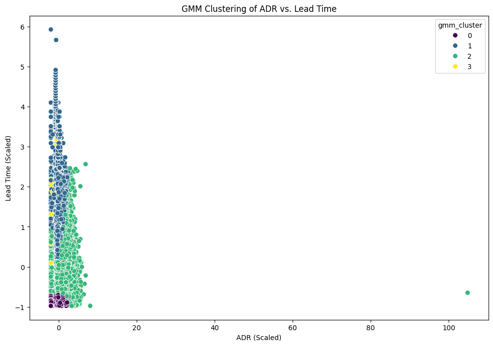

```python
gmm_probs = gmm.predict_proba(df[features])
df['gmm_cluster'] = gmm_probs.argmax(axis=1)

plt.figure(figsize=(12, 8))
sns.scatterplot(x='adr', y='lead_time', hue='gmm_cluster', data=df, palette='viridis', s=50, legend='full')
plt.title('GMM Clustering of ADR vs. Lead Time')
plt.xlabel('ADR (Scaled)')
plt.ylabel('Lead Time (Scaled)')
plt.show()
```

## 5. Evaluate Your Models

Business framing:

In business, models should be both useful and reliable. You’ll compare model quality using standard evaluation metrics.

- Calculate:
  - WCSS
  - Silhouette Score
  - Davies-Bouldin Index
- Compare both models

**Remember**:

- Lower WCSS = tighter, better-defined clusters
- Silhouette score ranges from -1 to 1. Higher values = better clustering
- Lower Davies-Boulding Index = better clustering

### In Your Response:

1. Which model performed better on the metrics?
2. Would you recommend KMeans or GMM for a business analyst? Why?

```python
# Add code here 🔧
```

```python
from sklearn.metrics import silhouette_score, davies_bouldin_score

# WCSS for KMeans
wcss = kmeans.inertia_
print(f"KMeans WCSS: {wcss}")

# Silhouette Score for KMeans
silhouette_kmeans = silhouette_score(df[features], df['kmeans_cluster'])
print(f"KMeans Silhouette Score: {silhouette_kmeans}")

# Davies-Bouldin Index for KMeans
davies_bouldin_kmeans = davies_bouldin_score(df[features], df['kmeans_cluster'])
print(f"KMeans Davies-Bouldin Index: {davies_bouldin_kmeans}")
```

```
KMeans WCSS: 133173.43653098555
KMeans Silhouette Score: 0.4200223435177494
KMeans Davies-Bouldin Index: 0.761058171812433
```

```python
from sklearn.metrics import silhouette_score, davies_bouldin_score

# Silhouette Score for GMM (using the assigned cluster labels)
silhouette_gmm = silhouette_score(df[features], df['gmm_cluster'])
print(f"GMM Silhouette Score: {silhouette_gmm}")

# Davies-Bouldin Index for GMM (using the assigned cluster labels)
davies_bouldin_gmm = davies_bouldin_score(df[features], df['gmm_cluster'])
print(f"GMM Davies-Bouldin Index: {davies_bouldin_gmm}")

# Note: WCSS is not directly applicable to GMM in the same way as KMeans.
```

```
GMM Silhouette Score: 0.1916987653837866
GMM Davies-Bouldin Index: 1.5413277325820185
```

### Evaluation Metrics Comparison

Here's a summary of the evaluation metrics for KMeans and GMM:

[output not shown]

## 6. Business Interpretation

Business framing:

What do these clusters mean in the real world? Could they represent solo travelers, families, or bargain shoppers?

- Review characteristics of each cluster (e.g. average `lead_time`, `special_requests`)
- Think from a marketing or hotel operations perspective

### In Your Response:

1. What do the segments represent in terms of guest behavior?
2. How could the hotel tailor services or promotions to each group?

```python
# Add code here 🔧
```

```python
print("KMeans Cluster Characteristics:")
display(df.groupby('kmeans_cluster')[['lead_time', 'adr', 'days_in_waiting_list', 'total_of_special_requests']].mean())
```

```
KMeans Cluster Characteristics:
```

| kmeans_cluster | lead_time | adr | days_in_waiting_list | total_of_special_requests |
| --- | --- | --- | --- | --- |
| 0 | -0.526417 | -0.498735 | -0.091559 | 0.525553 |
| 1 | 1.466987 | -0.258962 | -0.023704 | 0.444949 |
| 2 | 1.320411 | -0.328512 | 8.106562 | 0.069729 |
| 3 | -0.323110 | 1.229796 | -0.121471 | 0.794814 |

### ✍️ Your Response: 🔧

1. In terms of guest behavior group 0 with low ADR, low lead time, high requests it seems like it is a high maintence customer that pays the lowest price. In group 1 it shows a high lead lime, low ADR, and high requests which shows the person could be a budgeted planner maybe for a family (high requests). Group 2 is high in terms of the waitlist, high lead time, low adr, and low requests, sems to book very early and is willing to wait a long time for a low rate. Lastly, group 3 has the highest ADR, low lead time, and has the highest requests. This is probably a wealthy spontanious customer.
2. The hotel can tailor services/ premotions to each group. For group 0, they wouldn't want to lower the ADR but they can try to mix in add ons like dicounted breakfast and free parking to keep it budget friendly but still find ways for them to make money and increase customer satisfaction. For groups 1 and 2, they can premote an early bird pricing tactic to increase the hotel occupancy. In group 3, the hotel could focus on selling their premium services and ammenities.

## 7. Final Reflection

Business framing:

Many teams ask for "segmentation" without knowing how it works. You now have hands-on experience with two clustering techniques and how to present the results.

### In Your Response:

1. What was most challenging about unsupervised learning?
2. When would you use clustering instead of supervised models?
3. How would you explain the value of clustering to a non-technical manager?
4. How does this relate to your customized learning outcome you created in canvas?

### ✍️ Your Response: 🔧

1. The most challenging thing about unsupervised learning is there is not really a right answer in terms of how you find and use the data to find patterns. You have to find the 'why' behind the answers.
2. You would use clutering instead of supervised models if I were trying to find hidden patterns that you didnt already knowp existed.
3. To a non technical manager, I would describe clustering as finding unique characteristics within guests that we can use to accomidate and market to those clusters/ types of people.
4. This relates to my customized learning outcome of supply chain sustainability because being able to cluster suppliers or products based on their sustainability, we are able to find the problem areas. This relates to my opperations problem solving framework learning outcome because clustering is a very important step in turning a sustainability challenge into a measurable business problem.

## Submission Instructions

✅ **Before submitting:**

- Make sure all code cells are run and outputs are visible
- All markdown questions are answered thoughtfully
- Submit the assignment as an **HTML file** on Canvas

```python
!jupyter nbconvert --to html "assignment_09_LastnameFirstname.ipynb"
```